# Day2: マッチング

Jaehyun Song

2020-12-27

# パッケージとデータの読み込み

```r
# pacmanパッケージを利用しない場合
# library(tidyverse)
# library(MatchIt)
# library(WeightIt)
# library(BalanceR)
# library(cobalt)
pacman::p_load(tidyverse, MatchIt, WeightIt, BalanceR, cobalt)

# cobaltパッケージが提供するデータセットの読み込み
data("lalonde", package = "cobalt")

Day2_df <- lalonde
```

マッチングにおける古典的なデータセット、`lalonde`を読み込みました。`data(lalonde, package = "cobalt")`を入力するだけで、{cobalt}パッケージ内の`laonde`という名前のデータフレームが作業環境上に読み込まれます[^1]。このデータを`Day2_df`という名のオブジェクトとして改めて保存しておきます。

それでは、データの中身を確認してみましょう。普通にコンソール上で`lalonde`を打っても良いですが、`DT`パッケージの`datatable()`を使うと見やすい表形式で出力されます。

```r
# 今後、datatable()関数を使う予定はないので、DTパッケージを読み込まず、
# DT::datatable()を使用する
DT::datatable(Day2_df)
```

|  | treat | age | educ | race | married | nodegree | re74 | re75 | re78 |
| --- | --- | --- | --- | --- | --- | --- | --- | --- | --- |
| 1 | 1 | 37 | 11 | black | 1 | 1 | 0 | 0 | 9930.046 |
| 2 | 1 | 22 | 9 | hispan | 0 | 1 | 0 | 0 | 3595.894 |
| 3 | 1 | 30 | 12 | black | 0 | 0 | 0 | 0 | 24909.45 |
| 4 | 1 | 27 | 11 | black | 0 | 1 | 0 | 0 | 7506.146 |
| 5 | 1 | 33 | 8 | black | 0 | 1 | 0 | 0 | 289.7899 |
| 6 | 1 | 22 | 9 | black | 0 | 1 | 0 | 0 | 4056.494 |
| 7 | 1 | 23 | 12 | black | 0 | 0 | 0 | 0 | 0 |
| 8 | 1 | 32 | 11 | black | 0 | 1 | 0 | 0 | 8472.158 |
| 9 | 1 | 22 | 16 | black | 0 | 0 | 0 | 0 | 2164.022 |
| 10 | 1 | 33 | 12 | white | 1 | 0 | 0 | 0 | 12418.07 |

[output cut: 604 more lines]

分析に入る前に、名目変数である人種（`race`）をダミー変数にします。`race`は3種類の値で構成されているため、生成するダミー変数も3つとなります。

```r
Day2_df <- Day2_df %>%
  mutate(white    = if_else(race == "white",  1, 0),
         black    = if_else(race == "black",  1, 0),
         hispanic = if_else(race == "hispan", 1, 0),
         # 作成された以上の3変数をraceの後へ
         .after   = race)
```

# まずは単純差分から

`treat`変数の値ごとに結果変数である`re78`の平均値を計算してみましょう。

```r
Diff_Mean_df <- Day2_df %>%
    group_by(treat) %>%
    summarise(Outcome = mean(re78),
              .groups = "drop")

Diff_Mean_df
```

```
## # A tibble: 2 x 2
##   treat Outcome
##   <int>   <dbl>
## 1     0   6984.
## 2     1   6349.
```

この結果を可視化するコードは以下の通りです。

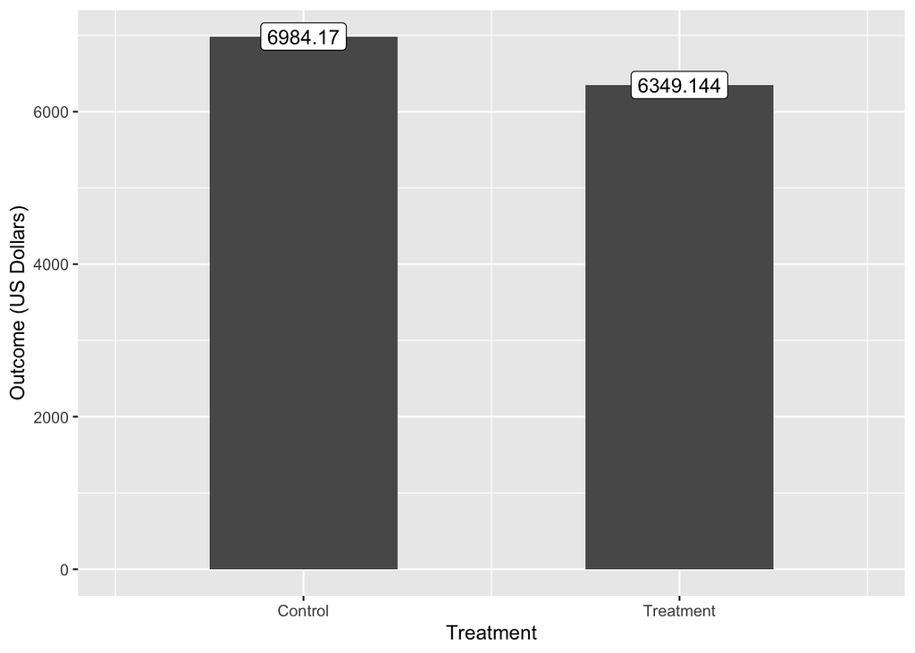

```r
Diff_Mean_df %>%
  ggplot() +
  geom_bar(aes(x = treat, y = Outcome),
           stat = "identity", width = 0.5) +
  geom_label(aes(x = treat, y = Outcome,
                 label = round(Outcome, 3))) +
  labs(x = "Treatment",
       y = "Outcome (US Dollars)") +
  # scale_x_continuous()を使って0/1をControl/Treatmentに置換する
  # 目盛りはX軸上の0と1、各目盛りのラベルはControlとTreatmentに
  scale_x_continuous(breaks = c(0, 1), labels = c("Control", "Treatment")) +
  coord_cartesian(xlim = c(-0.5, 1.5))
```

ちなみに、以上の結果は単回帰分析からも確認可能です (ただし、統計的に有意ではない)。

```r
Raw_Fit1 <- lm(re78 ~ treat, data = Day2_df)
summary(Raw_Fit1)
```

```
##
## Call:
## lm(formula = re78 ~ treat, data = Day2_df)
##
## Residuals:
##    Min     1Q Median     3Q    Max
##  -6984  -6349  -2048   4100  53959
##
## Coefficients:
##             Estimate Std. Error t value Pr(>|t|)
## (Intercept)   6984.2      360.7  19.362   <2e-16
## treat         -635.0      657.1  -0.966    0.334
##
## Residual standard error: 7471 on 612 degrees of freedom
## Multiple R-squared:  0.001524,   Adjusted R-squared:  -0.0001079
## F-statistic: 0.9338 on 1 and 612 DF,  p-value: 0.3342
```

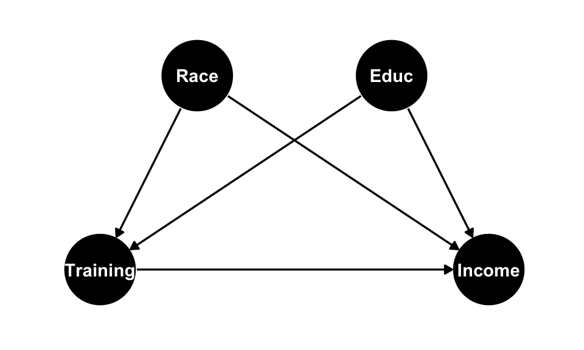

本当にそうなのか、共変量のバランスチェックをしてみましょう。もし、処置有無によって回答者の社会経済的要因に大きな差があれば、内生性が存在する証拠になります。ここでは担当教員が作成しました{BalanceR}パッケージを使います。

```r
Blc_Chk <- Day2_df %>%
  BalanceR(group = treat, cov = c(age, educ, white:re75))
```

{BalanceR}パッケージで共変量を指定する際、`:`演算子が使用可能です。`white:re75`は、データセットの`white`から`re75`変数までをすべて指定することを意味します。Rコンソール上で変数名のみを出力するには`names()`関数を使用します。

```r
names(Day2_df)
```

```
##  [1] "treat"    "age"      "educ"     "race"     "white"    "black"
##  [7] "hispanic" "married"  "nodegree" "re74"     "re75"     "re78"
```

`white`から`re75`まで`black`、`hispanic`、`married`などの変数がありますが、これらを一々指定せず、`:`を使えば一気に指定することができます。それではバランスチェックの結果を確認してみましょう。

```r
Blc_Chk
```

```
##   Covariate   Mean:0     SD:0   Mean:1     SD:1   SB:0-1
## 1       age   28.030   10.787   25.816    7.155   24.190
## 2      educ   10.235    2.855   10.346    2.011   -4.476
## 3     white    0.655    0.476    0.097    0.297  140.799
## 4     black    0.203    0.403    0.843    0.365 -167.083
## 5  hispanic    0.142    0.350    0.059    0.237   27.740
## 6   married    0.513    0.500    0.189    0.393   72.076
## 7  nodegree    0.597    0.491    0.708    0.456  -23.549
## 8      re74 5619.237 6788.751 2095.574 4886.620   59.575
## 9      re75 2466.484 3291.996 1532.055 3219.251   28.700
```

| Covariate | Mean:0 | SD:0 | Mean:1 | SD:1 | SB:0-1 |
| --- | --- | --- | --- | --- | --- |
| age | 28.030 | 10.787 | 25.816 | 7.155 | 24.190 |
| educ | 10.235 | 2.855 | 10.346 | 2.011 | -4.476 |
| white | 0.655 | 0.476 | 0.097 | 0.297 | 140.799 |
| black | 0.203 | 0.403 | 0.843 | 0.365 | -167.083 |
| hispanic | 0.142 | 0.350 | 0.059 | 0.237 | 27.740 |
| married | 0.513 | 0.500 | 0.189 | 0.393 | 72.076 |
| nodegree | 0.597 | 0.491 | 0.708 | 0.456 | -23.549 |
| re74 | 5619.237 | 6788.751 | 2095.574 | 4886.620 | 59.575 |
| re75 | 2466.484 | 3291.996 | 1532.055 | 3219.251 | 28.700 |

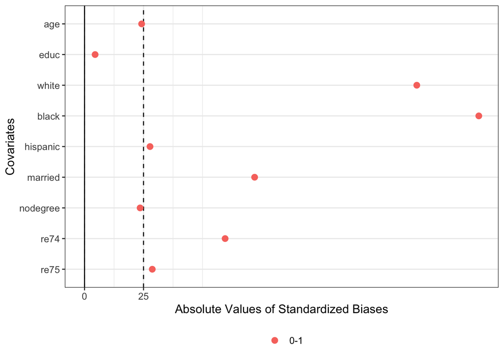

```r
# 標準化バイアスの可視化
# 絶対値変換。SB = 25に破線
plot(Blc_Chk, abs = TRUE, vline = 25)
```

かなり緩めの基準である25を採用しても、人種（黒人）、結婚有無、74年の所得のバランスが非常によくありません。内生性があると判断して良いでしょう。以下では様々な方法を使い、この内生性に対処していきたいと思います。

# 内生性への対処

## 重回帰分析

つづいて、重回帰分析もしてみましょう。用いる共変量は年齢、教育水準、黒人ダミー、ヒスパニックダミー、既婚ダミー、学位なしダミー、74・75年の所得です。`lm()`関数を使用し、78年の所得をこちらの変数に回帰させます。

$$\begin{align}
\textrm{re78} = & \beta_0 + \beta_1 \textrm{treat} + \beta_2 \textrm{age} + \beta_3 \textrm{educ} + \\
& \beta_4 \textrm{black} + \beta_5 \textrm{hispanic} + \beta_6 \textrm{married} + \beta_7 \textrm{nodegree} + \beta_8 \textrm{re74} + \beta_9 \textrm{re75}.
\end{align}$$

```r
Raw_Fit2 <- lm(re78 ~ treat + age + educ + black + hispanic + married +
                   nodegree + re74 + re75, data = Day2_df)
summary(Raw_Fit2) # 処置効果は約1548
```

```
##
## Call:
## lm(formula = re78 ~ treat + age + educ + black + hispanic + married +
##     nodegree + re74 + re75, data = Day2_df)
##
## Residuals:
##    Min     1Q Median     3Q    Max
## -13595  -4894  -1662   3929  54570
##
## Coefficients:
##               Estimate Std. Error t value Pr(>|t|)
## (Intercept)  6.651e+01  2.437e+03   0.027   0.9782
## treat        1.548e+03  7.813e+02   1.982   0.0480
## age          1.298e+01  3.249e+01   0.399   0.6897
## educ         4.039e+02  1.589e+02   2.542   0.0113
## black       -1.241e+03  7.688e+02  -1.614   0.1071
## hispanic     4.989e+02  9.419e+02   0.530   0.5966
## married      4.066e+02  6.955e+02   0.585   0.5590
## nodegree     2.598e+02  8.474e+02   0.307   0.7593
## re74         2.964e-01  5.827e-02   5.086 4.89e-07
## re75         2.315e-01  1.046e-01   2.213   0.0273
##
## Residual standard error: 6948 on 604 degrees of freedom
## Multiple R-squared:  0.1478, Adjusted R-squared:  0.1351
## F-statistic: 11.64 on 9 and 604 DF,  p-value: < 2.2e-16
```

共変量を統制したら処置変数の係数は約1548.244ドルです。先ほどの単回帰分析の結果とは違って、統計的に有意な正の効果が確認されていますね。

## マハラノビス最近傍マッチング

重回帰分析は非常にシンプルで便利な分析方法ですが、いくつかの欠点があります。まず、重回帰分析は変数間の関係（線形結合）および誤差項の分布（正規分布）などを仮定したパラメトリック分析になります。この場合、同じ共変量を持たないケースであっても、勝手に予測を行います。重回帰分析における処置変数の解釈は「他の共変量がすべて同じ」場合の処置効果になります。これは、共変量がすべて同じ場合における（最初に見た）単純差分のようなものです。しかし、「他の共変量がすべて同じ」ケースが存在しない可能性があります。特に、共変量が多く、連続変数の場合、共変量がすべて同じことは実質あり得ないか、非常に少ないケースに限定されます。一方、マッチングを行うと、「他の共変量がすべて同じ」、または「非常に似ている」ケース間で比較を行います。

ここでは以下の4つの手法を紹介します。

1. マッチング
   - マハラノビス距離最近傍マッチング
   - Coarsened Exact Matching (CEM)
   - 傾向スコアマッチング
2. 逆確率重み付け

まずは、マハラノビス最近傍マッチングから始めましょう。だいたいのマッチング手法は{MatchIt}パッケージで解決できます。マッチングデータセットを作成する関数は`matchit()`関数であり、使い方は

```r
matchit(処置変数 ~ 共変量1 + ... + 共変量k,
            method = "nearest", distance = "mahalanobis")
```

のように入力します。`method = "nearest"`は最近傍マッチングを意味し、`distance = "mahalanobis"`はマハラノビス距離を意味します。早速やってみましょう。

```r
MH.Matching <- matchit(treat ~ age + educ + black + hispanic + married +
                           nodegree + re74 + re75, data = Day2_df,
                       method = "nearest", distance = "mahalanobis")
```

バランスチェックは数値的に確認する方法と視覚的にする方法があります。まずは、数値的に確認してみましょう。

```r
# バランスチェック (Numerical)
summary(MH.Matching)
```

```
##
## Call:
## matchit(formula = treat ~ age + educ + black + hispanic + married +
##     nodegree + re74 + re75, data = Day2_df, method = "nearest",
##     distance = "mahalanobis")
##
## Summary of Balance for All Data:
##          Means Treated Means Control Std. Mean Diff. Var. Ratio eCDF Mean
## age            25.8162       28.0303         -0.3094     0.4400    0.0813
## educ           10.3459       10.2354          0.0550     0.4959    0.0347
## black           0.8432        0.2028          1.7615          .    0.6404
## hispanic        0.0595        0.1422         -0.3498          .    0.0827
## married         0.1892        0.5128         -0.8263          .    0.3236
## nodegree        0.7081        0.5967          0.2450          .    0.1114
## re74         2095.5737     5619.2365         -0.7211     0.5181    0.2248
## re75         1532.0553     2466.4844         -0.2903     0.9563    0.1342
##          eCDF Max
## age        0.1577
## educ       0.1114
## black      0.6404
## hispanic   0.0827
## married    0.3236
## nodegree   0.1114
## re74       0.4470
## re75       0.2876
##
##
## Summary of Balance for Matched Data:
##          Means Treated Means Control Std. Mean Diff. Var. Ratio eCDF Mean
## age            25.8162       25.5351          0.0393     0.7451    0.0341
## educ           10.3459       10.4703         -0.0618     0.8918    0.0122
## black           0.8432        0.2595          1.6057          .    0.5838
## hispanic        0.0595        0.1297         -0.2971          .    0.0703
## married         0.1892        0.4486         -0.6625          .    0.2595
## nodegree        0.7081        0.6108          0.2140          .    0.0973
## re74         2095.5737     2545.7229         -0.0921     1.2602    0.0748
## re75         1532.0553     1645.4710         -0.0352     1.3141    0.0386
##          eCDF Max Std. Pair Dist.
## age        0.1243          0.3188
## educ       0.0973          0.2285
```

[output cut: 9 more lines]

```
## age                 87.3       64.2      58.1     21.2
## educ               -12.5       83.7      64.8     12.6
## black                8.8          .       8.8      8.8
## hispanic            15.1          .      15.1     15.1
## married             19.8          .      19.8     19.8
## nodegree            12.6          .      12.6     12.6
## re74                87.2       64.8      66.7     23.8
## re75                87.9     -511.2      71.2     36.1
##
## Sample Sizes:
##           Control Treated
## All           429     185
## Matched       185     185
## Unmatched     244       0
## Discarded       0       0
```

つづいて視覚的な方法です。

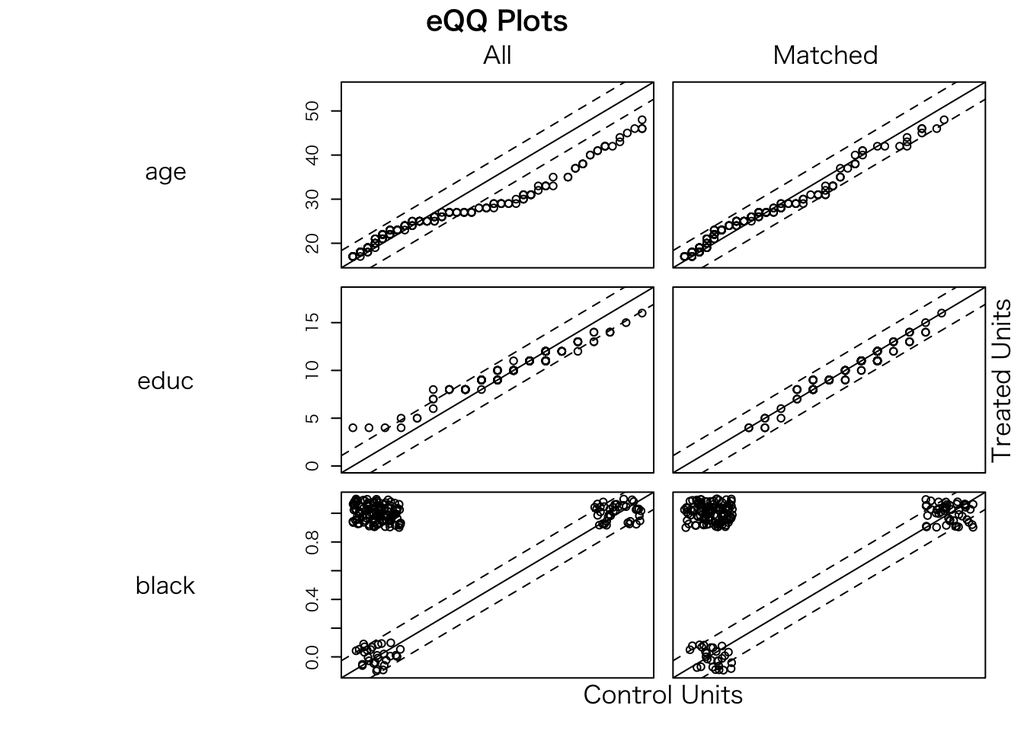

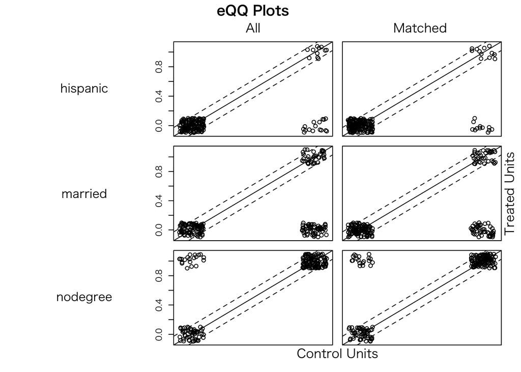

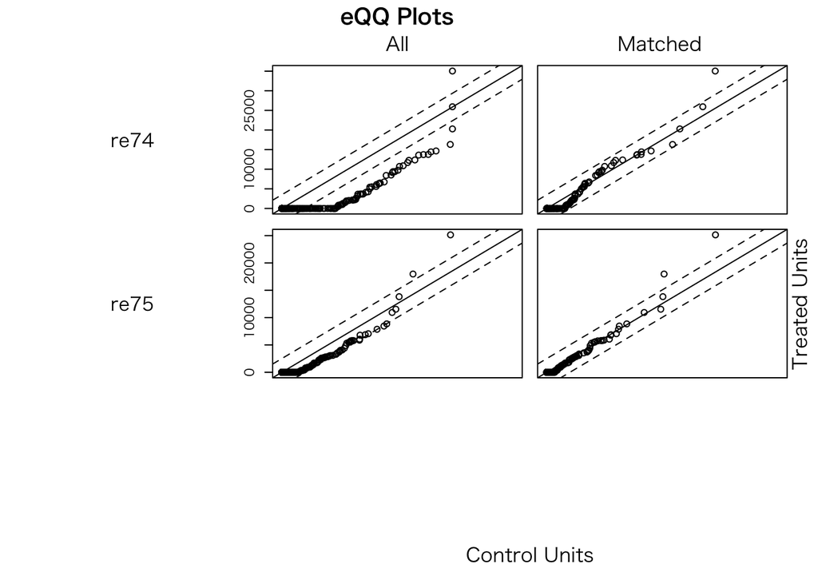

```r
# バランスチェック (Graphical): QQプロットによるバランスチェック
plot(MH.Matching)
```

各ポイントが45度直線上に並ぶのが理想的なバランシングです。バランスが改善されていることが確認できます。

もっと直感的なバランスチェックの方法として{BalanceR}パッケージと同様、標準化バイアスを使う方法です。マッチング前後のバランスを同時に確認するには{cobalt}パッケージの`love.plot`が便利です。

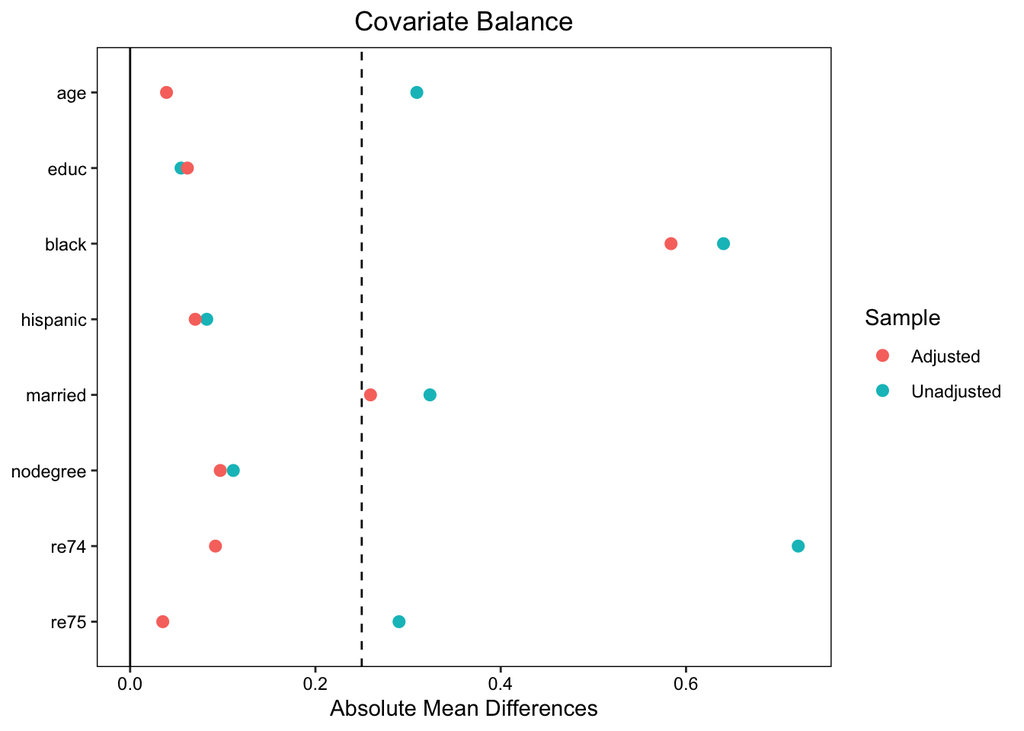

```r
love.plot(MH.Matching, thresholds = 0.25, abs = TRUE)
```

`thresholds`引数は垂直線（破線）の位置、`abs`は標準化バイアスを絶対値で示すことを意味します。マッチング後の標準化バイアス（Adjusted; 赤い点）が0.25より左側に位置している場合、バランスしていると判断できます。他にもマッチング後の標準化バイアスがマッチング前（Unadjusted; 青い点）より改善されるいるか否かも判断できます。今回の例だと、大幅にバランスが改善されました。`black`はまだバランスが取れておりませんが、それでも大幅に改善されていることが分かります。

それではATEを推定してみましょう。推定方法としてはノンパラメトリックな方法とパラメトリック方法がありますが、結果は変わりません。ノンパラメトリックな方法はペアごとの差分を計算し、その平均値を求める方法ですが、マッチング済みのデータに対し、処置変数を結果変数を回帰させることも、結果的には同じことを行うことになります。したがって、もっと簡単なパラメトリック方法でATEを推定します。ノンパラメトリック方法によるATEの推定は本資料の付録を参照してください。

回帰分析を行うためにはデータが必要ですね。つまり、マッチングされないケースをデータから除去する必要があります。したがって、マッチングされた後のデータセットを抽出する必要があります。使う関数は`match.data()`関数です。

```r
# マッチング後データを抽出
MH.Data <- match.data(MH.Matching)
```

マッチングデータが取れたら、その中身を確認してみましょう。

```r
dim(MH.Data)
```

```
## [1] 370  14
```

```r
MH.Data
```

|  | treat | age | educ | race | white | black | hispanic | married | nodegree | re74 | re75 | re78 | weights | subclass |
| --- | --- | --- | --- | --- | --- | --- | --- | --- | --- | --- | --- | --- | --- | --- |
| 1 | 1 | 37 | 11 | black | 0 | 1 | 0 | 1 | 1 | 0 | 0 | 9930.046 | 1 | 1 |
| 2 | 1 | 22 | 9 | hispan | 0 | 0 | 1 | 0 | 1 | 0 | 0 | 3595.894 | 1 | 98 |
| 3 | 1 | 30 | 12 | black | 0 | 1 | 0 | 0 | 0 | 0 | 0 | 24909.45 | 1 | 109 |
| 4 | 1 | 27 | 11 | black | 0 | 1 | 0 | 0 | 1 | 0 | 0 | 7506.146 | 1 | 120 |
| 5 | 1 | 33 | 8 | black | 0 | 1 | 0 | 0 | 1 | 0 | 0 | 289.7899 | 1 | 131 |
| 6 | 1 | 22 | 9 | black | 0 | 1 | 0 | 0 | 1 | 0 | 0 | 4056.494 | 1 | 142 |
| 7 | 1 | 23 | 12 | black | 0 | 1 | 0 | 0 | 0 | 0 | 0 | 0 | 1 | 153 |
| 8 | 1 | 32 | 11 | black | 0 | 1 | 0 | 0 | 1 | 0 | 0 | 8472.158 | 1 | 164 |
| 9 | 1 | 22 | 16 | black | 0 | 1 | 0 | 0 | 0 | 0 | 0 | 2164.022 | 1 | 175 |
| 10 | 1 | 33 | 12 | white | 1 | 0 | 0 | 1 | 0 | 0 | 0 | 12418.07 | 1 | 2 |

[output cut: 360 more lines]

データのサイズは370行14列です。この370行には意味があります。それは処置群の大きさの2倍という点です。多くの場合、マッチングから計算される処置効果はATEではなく、ATTです。したがって、処置群のデータを100%活用し、統制群から共変量が最も近いケースを抽出&マッチングすることになります。だから、マッチング後のサンプルサイズは処置群のサイズの2倍になります。

それでは職業訓練のATTを推定します。方法は簡単です。このマッチング後のデータを用い、単回帰分析を行うのみです。

```r
# 処置効果の確認 (Model-Based)
MH_Fit <- lm(re78 ~ treat, data = MH.Data)

summary(MH_Fit)
```

```
##
## Call:
## lm(formula = re78 ~ treat, data = MH.Data)
##
## Residuals:
##    Min     1Q Median     3Q    Max
##  -6349  -5780  -2093   3239  53959
##
## Coefficients:
##             Estimate Std. Error t value Pr(>|t|)
## (Intercept)   5842.1      528.1  11.062   <2e-16
## treat          507.0      746.9   0.679    0.498
##
## Residual standard error: 7183 on 368 degrees of freedom
## Multiple R-squared:  0.001251,   Adjusted R-squared:  -0.001463
## F-statistic: 0.4609 on 1 and 368 DF,  p-value: 0.4976
```

処置効果は約507.043ドルであり、付録にあるノンパラメトリック推定値と一致していることが分かります。今回の結果は重回帰分析よりも推定値が低めであり、統計的に有意に職業訓練の効果があったとは言えないという結果が得られましたね。

ちなみに、{MatchIt}パッケージを使った最近傍マッチングのの結果は行う度に変化することがあります。なぜなら、{MatchIt}パッケージを使った最近傍マッチングの場合、処置群 (統制群)から一つのケースを選択し、最も近い統制群 (処置群)とマッチングさせます。マッチングされたケースは次のステップからはマッチング対象から除外されます。また、1:1マッチングの場合、同距離に複数のマッチング対象があると、ランダムに1つのみを選択します。最近傍マッチングを用いる際は、複数推定を行い、推定が安定するかを確認し、不安定な場合は他の手法を使うか、k-最近傍マッチングなどを使ってみましょう。

## Coarsened Exact Matching

CEMはマハラノビス最近傍マッチング同様、`matchit()`関数を使います。ただし、`cem`パッケージをインストールしておく必要があります。まず、Exact Matching類の手法は距離を図る必要がないので、`distance`引数は不要です。`method = ...`引数を`"nearest"` (最近傍)から`"cem"`に替えるだけです。

マッチングをしたら`match.data()`でマッチングされたデータを抽出します。

```r
CEM.Matching <- matchit(treat ~ age + educ + black + hispanic + married +
                            nodegree + re74 + re75, data = Day2_df,
                       method = "cem")

summary(CEM.Matching)
```

```
##
## Call:
## matchit(formula = treat ~ age + educ + black + hispanic + married +
##     nodegree + re74 + re75, data = Day2_df, method = "cem")
##
## Summary of Balance for All Data:
##          Means Treated Means Control Std. Mean Diff. Var. Ratio eCDF Mean
## age            25.8162       28.0303         -0.3094     0.4400    0.0813
## educ           10.3459       10.2354          0.0550     0.4959    0.0347
## black           0.8432        0.2028          1.7615          .    0.6404
## hispanic        0.0595        0.1422         -0.3498          .    0.0827
## married         0.1892        0.5128         -0.8263          .    0.3236
## nodegree        0.7081        0.5967          0.2450          .    0.1114
## re74         2095.5737     5619.2365         -0.7211     0.5181    0.2248
## re75         1532.0553     2466.4844         -0.2903     0.9563    0.1342
##          eCDF Max
## age        0.1577
## educ       0.1114
## black      0.6404
## hispanic   0.0827
## married    0.3236
## nodegree   0.1114
## re74       0.4470
## re75       0.2876
##
##
## Summary of Balance for Matched Data:
##          Means Treated Means Control Std. Mean Diff. Var. Ratio eCDF Mean
## age            21.6462       21.2936          0.0493     0.8909    0.0130
## educ           10.3692       10.2795          0.0446     0.8894    0.0100
## black           0.8615        0.8615          0.0000          .    0.0000
## hispanic        0.0308        0.0308          0.0000          .    0.0000
## married         0.0308        0.0308          0.0000          .    0.0000
## nodegree        0.6769        0.6769          0.0000          .    0.0000
## re74          489.0612      697.6115         -0.0427     1.3916    0.0435
## re75          362.4365      520.8378         -0.0492     0.8501    0.0403
##          eCDF Max Std. Pair Dist.
## age        0.0897          0.1373
## educ       0.1000          0.1949
## black      0.0000          0.0000
```

[output cut: 9 more lines]

```
## educ                18.8       83.3      71.2     10.2
## black              100.0          .     100.0    100.0
## hispanic           100.0          .     100.0    100.0
## married            100.0          .     100.0    100.0
## nodegree           100.0          .     100.0    100.0
## re74                94.1       49.7      80.6     30.2
## re75                83.0     -263.5      70.0     44.4
##
## Sample Sizes:
##               Control Treated
## All            429.       185
## Matched (ESS)   41.29      65
## Matched         75.        65
## Unmatched      354.       120
## Discarded        0.         0
```

つづいて、`cobalt::love.plot()`を使用して、バランスチェックを行います。

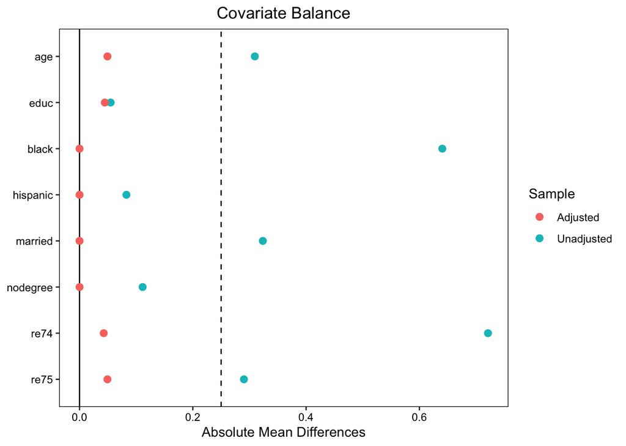

```r
love.plot(CEM.Matching, thresholds = 0.25, abs = TRUE)
```

CEMの場合、マハラノビス距離最近傍マッチングよりもバランスが大きく改善されたことが分かります。その理由は簡単です。最近傍マッチングの場合、最も近いケースであれば、どれほど離れていてもマッチングされます。一方、CEMは正確マッチングの一種であるため、ある程度離れているケースを捨ててしまうからです。結局は共変量が非常に近いケースのみを残すことになります。

それでは、`match.data()`関数を使ってマッチング後のデータを抽出してみましょう。

```r
CEM.Data <- match.data(CEM.Matching)
```

```r
CEM.Data
```

|  | treat | age | educ | race | white | black | hispanic | married | nodegree | re74 | re75 | re78 | weights | subclass |
| --- | --- | --- | --- | --- | --- | --- | --- | --- | --- | --- | --- | --- | --- | --- |
| 2 | 1 | 22 | 9 | hispan | 0 | 0 | 1 | 0 | 1 | 0 | 0 | 3595.894 | 1 | 1 |
| 4 | 1 | 27 | 11 | black | 0 | 1 | 0 | 0 | 1 | 0 | 0 | 7506.146 | 1 | 2 |
| 6 | 1 | 22 | 9 | black | 0 | 1 | 0 | 0 | 1 | 0 | 0 | 4056.494 | 1 | 3 |
| 7 | 1 | 23 | 12 | black | 0 | 1 | 0 | 0 | 0 | 0 | 0 | 0 | 1 | 4 |
| 9 | 1 | 22 | 16 | black | 0 | 1 | 0 | 0 | 0 | 0 | 0 | 2164.022 | 1 | 5 |
| 11 | 1 | 19 | 9 | black | 0 | 1 | 0 | 0 | 1 | 0 | 0 | 8173.908 | 1 | 6 |
| 12 | 1 | 21 | 13 | black | 0 | 1 | 0 | 0 | 0 | 0 | 0 | 17094.64 | 1 | 4 |
| 13 | 1 | 18 | 8 | black | 0 | 1 | 0 | 0 | 1 | 0 | 0 | 0 | 1 | 7 |
| 15 | 1 | 17 | 7 | black | 0 | 1 | 0 | 0 | 1 | 0 | 0 | 3023.879 | 1 | 7 |
| 16 | 1 | 19 | 10 | black | 0 | 1 | 0 | 0 | 1 | 0 | 0 | 3228.503 | 1 | 8 |

[output cut: 130 more lines]

処置効果の推定は重み付き回帰分析 (WLS)で行います。既存の`lm()`関数に`weight = ...`引数を追加し、データ内の重み列をしてするだけです。

```r
# 処置効果の確認
# weight = Wが追加されていることを確認
CEM_Fit <- lm(re78 ~ treat, data = CEM.Data, weights = weights)

# 処置効果の確認
summary(CEM_Fit)
```

```
##
## Call:
## lm(formula = re78 ~ treat, data = CEM.Data, weights = weights)
##
## Weighted Residuals:
##    Min     1Q Median     3Q    Max
##  -8943  -5196  -1580   1970  53971
##
## Coefficients:
##             Estimate Std. Error t value Pr(>|t|)
## (Intercept)   5265.8      850.5   6.192  6.4e-09
## treat         1070.9     1248.1   0.858    0.392
##
## Residual standard error: 7365 on 138 degrees of freedom
## Multiple R-squared:  0.005306,   Adjusted R-squared:  -0.001902
## F-statistic: 0.7362 on 1 and 138 DF,  p-value: 0.3924
```

今回、処置効果の推定値は約1070.907ドルです。

## 傾向スコアマッチング

傾向スコアマッチングも、これまでのコマンドとほぼ同じです。マハラノビス最近傍マッチングのコマンドから`distance = ...`引数を抜けば、傾向スコアマッチングができます[^3]。また、`replace`引数に`TRUE`を指定します。これは一度マッチングしたケースを捨てずに、次のマッチングにも使うことを意味します。デフォルトは`FALSE`となっており、この場合、一度マッチングされたケースは二度とマッチングされません。したがって、`replace = TRUE`を指定した方が共変量バランスがより改善されます。

```r
PS.Matching <- matchit(treat ~ age + educ + black + hispanic + married +
                           nodegree + re74 + re75, data = Day2_df,
                       method = "nearest", replace = TRUE)
```

処置効果の推定の前に、バランスが取れているかどうかを確認してみましょう。これまではQQプロットのみでバランスチェックをしましたが、今回はヒストグラムとJitterプロットで確認します。

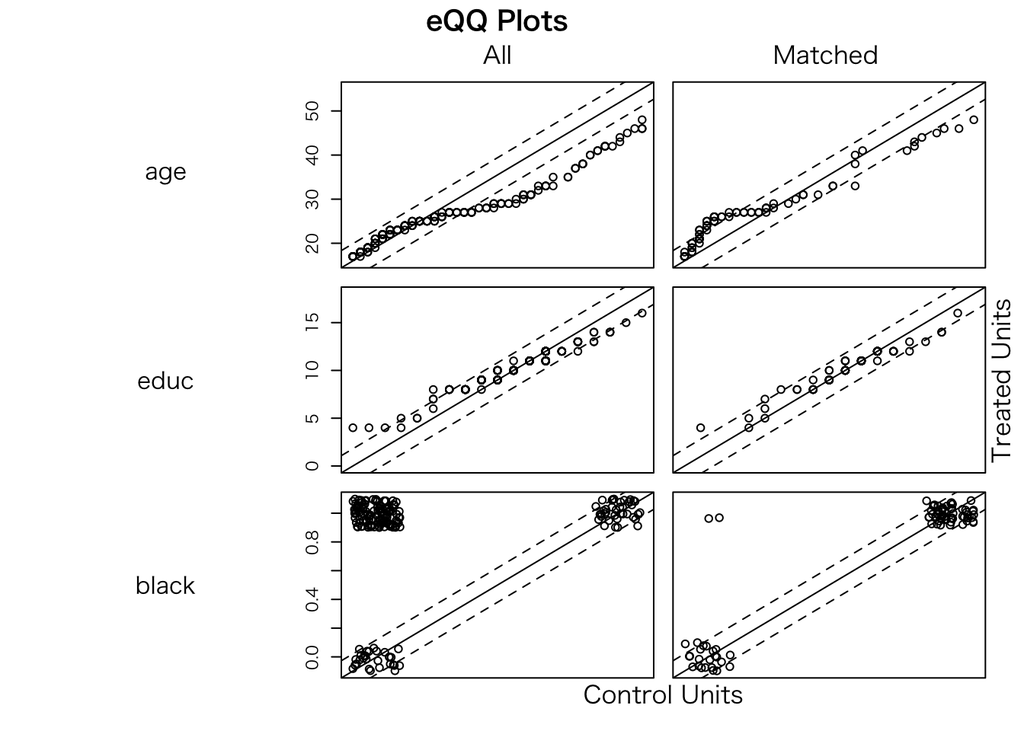

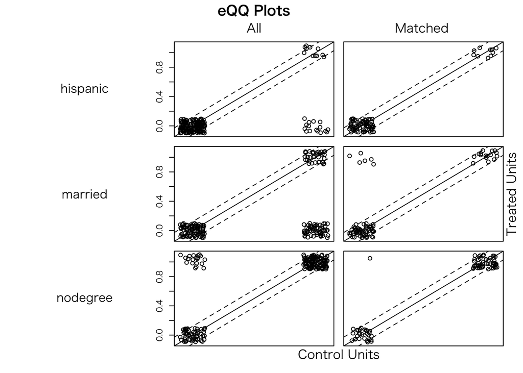

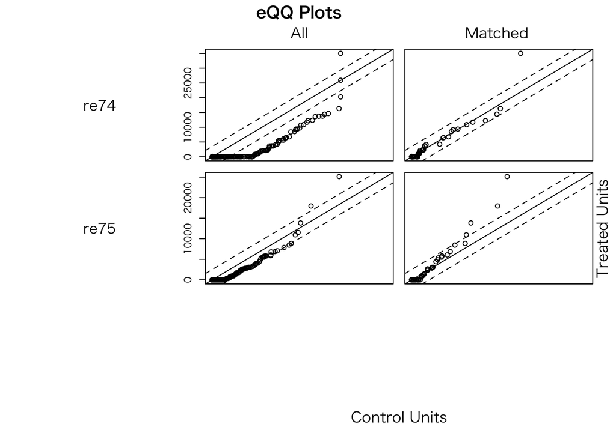

```r
# 1. QQプロットによるバランスチェック
plot(PS.Matching)
```

QQプロットを見ると、バランスが多少改善されていることが分かります。

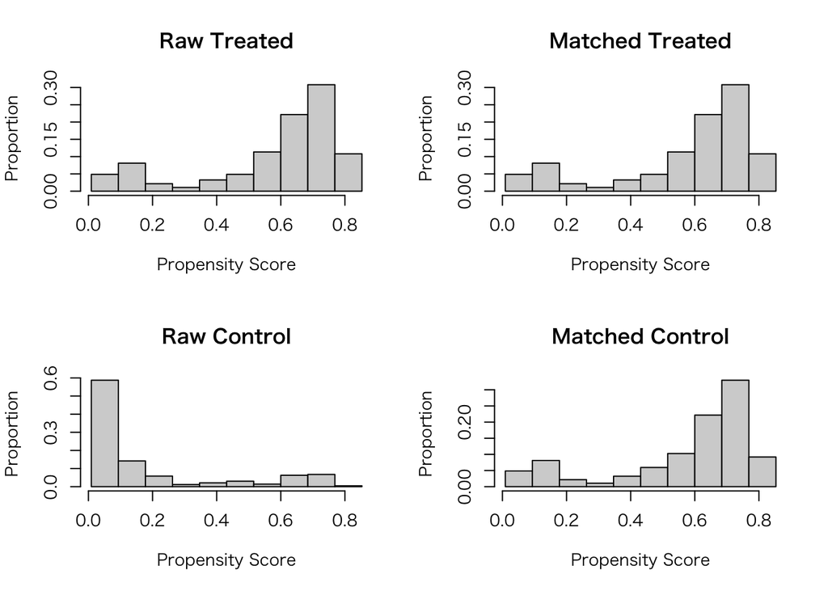

```r
# 2. ヒストグラムによるバランスチェック
plot(PS.Matching, type = "hist")
```

ヒストグラムからもバランスが改善されたことが確認できますね。出来れば、ヒストグラムを重ねて比較したいんですが、残念です。あとでオーバーラップされたヒストグラムの作成方法について解説します。

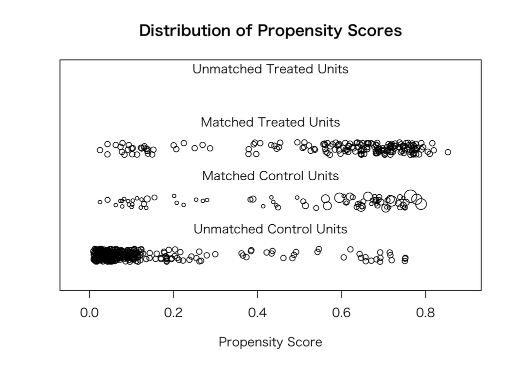

```
## [1] "To identify the units, use first mouse button; to stop, use second."
```

```
## integer(0)
```

```r
# 3. 散布図によるバランスチェック
par(mfrow = c(1, 1))
plot(PS.Matching, type = "jitter")
```

散布図をみると、傾向スコア ($e$)が小さいケースがマッチングから除外されたことが分かります。実際、処置群には傾向スコアが小さいケースが非常に少ないため、これは妥当な結果でしょう。

むろん、おなじみの`cobalt::love.plot()`でもバランスチェックができます。

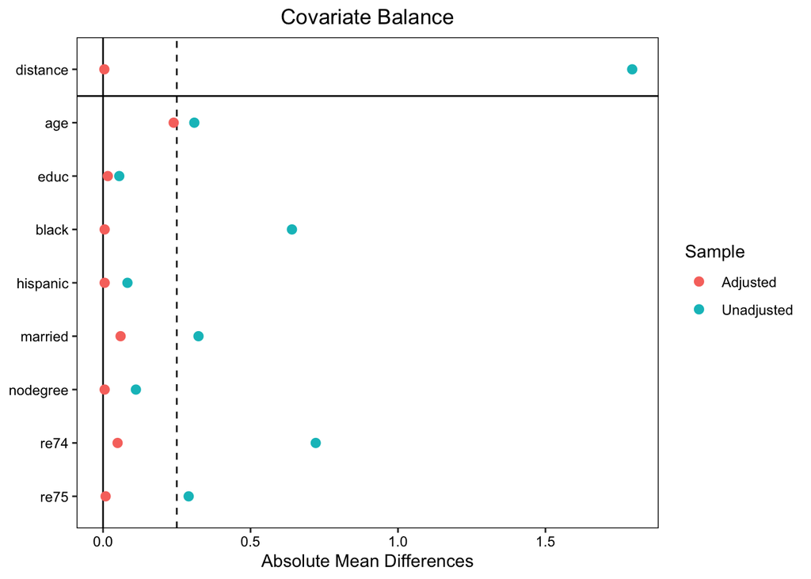

```r
love.plot(PS.Matching, thresholds = 0.25, abs = TRUE)
```

それでは、ATT推定のためにマッチング後のデータを抽出します。

```r
# 傾向スコアマッチング後のデータセットを抽出
PS.Data <- match.data(PS.Matching)
```

傾向スコアを用いたATTをの推定もこれまでと同様、回帰分析を用います。普通の回帰分析ですが、用いるデータは傾向スコアでマッチングされたデータのみになります。ただし、今回は重み付け変数である`weights`を指定する必要があります。なぜなら、統制群から1つのケースが何回もマッチングされる可能性があるからです。統制群のあるケースが数回マッチングされても`PS.Data`にそのケースは1つしかありません。この場合は重みをより高く付ける必要があります。幸い、{MatchIt}パッケージはその重みの自動的に計算してくれます。具体的にはCEMと同様、`weights`変数が`PS.Data`に追加されます。

```r
# 処置効果の推定
PS_Fit <- lm(re78 ~ treat, data = PS.Data, weights = weights)

summary(PS_Fit)
```

```
##
## Call:
## lm(formula = re78 ~ treat, data = PS.Data, weights = weights)
##
## Weighted Residuals:
##    Min     1Q Median     3Q    Max
##  -9903  -5095  -1878   3229  53959
##
## Coefficients:
##             Estimate Std. Error t value Pr(>|t|)
## (Intercept)   4381.2      811.6   5.398  1.5e-07
## treat         1967.9      971.4   2.026   0.0438
##
## Residual standard error: 7259 on 263 degrees of freedom
## Multiple R-squared:  0.01537,    Adjusted R-squared:  0.01162
## F-statistic: 4.104 on 1 and 263 DF,  p-value: 0.04378
```

処置効果は約1967.94ドルでした。

ちなみに、講義スライド24ページ目の例を{MatchIt}パッケージを使うと以下のようなコードになります。

```r
# 講義スライドのデータ
PS.df2 <- read.csv("Day2_Data2.csv")

Example_Mat <- matchit(Treat ~ Age + Edu,
        data = PS.df2, method = "nearest", replace = TRUE)

Example_Data <- match.data(Example_Mat)

Example_Fit <- lm(Outcome ~ Treat, data = Example_Data, weights = weights)

summary(Example_Fit)
```

```
##
## Call:
## lm(formula = Outcome ~ Treat, data = Example_Data, weights = weights)
##
## Weighted Residuals:
##     Min      1Q  Median      3Q     Max
## -3.0384 -0.9495 -0.6714  1.2727  3.9539
##
## Coefficients:
##             Estimate Std. Error t value Pr(>|t|)
## (Intercept)   4.9091     0.8297   5.917 2.83e-05
## Treat         1.8182     1.0314   1.763   0.0983
##
## Residual standard error: 2.032 on 15 degrees of freedom
## Multiple R-squared:  0.1716, Adjusted R-squared:  0.1164
## F-statistic: 3.108 on 1 and 15 DF,  p-value: 0.09829
```

手計算から得られた結果と一致することが分かります。

## IPW推定量

最後にATTでなく、ATEが推定の対象となるIPW推定量を計算してみましょう。{WeightIt}パッケージを使用すれば便利ですが、ここではあえて使わずにIPW推定量を計算してみましょう。こうすることでIPWが具体的にどのような仕組みで推定されるかが理解できるはずです。一通りの推定が終わりましたら{WeightIt}パッケージの使い方も紹介します。

### パッケージを使わない方法

まずは、傾向スコアの算出ですが、ここではロジスティック回帰分析で傾向スコアを計算します[^4]。

```r
# Logitで傾向スコアを推定
PS <- glm(treat ~ age + educ + black + hispanic + married + nodegree +
              re74 + re75, data = Day2_df,
          family = binomial("logit"))
```

続いて、既存のデータフレームに傾向スコアが格納された列を追加します。まず、既存の`lalonde`データセットを`Matching.df`という名前で複製します。

新しいデータフレームに`PS`という列を作成し、ここに傾向スコアを格納します。傾向スコアはロジスティック回帰分析のオブジェクトに`$fitted.values`を加えるだけで抽出できます。

```r
# lalondeデータフレームを複製
Matching.df <- Day2_df

# 傾向スコア推定値をデータフレーム内に格納
Matching.df$PS <- PS$fitted.values
```

次は、各ケースの重みを計算し、`W`という新しい列として追加します。傾向スコアは、もしケースが処置群 (`treat == 1`)なら、$\frac{1}{e}$を、統制群 (`treat == 0`)なら$\frac{1}{(1-e)}$となります。

```r
# 重み変数を作成
## ケースが処置群なら、重み = 傾向スコアの逆数
## ケースが統制群あら、重み = (1 - 傾向スコア)の逆数
Matching.df <- Matching.df %>%
    mutate(W = ifelse(treat == 1, (1 / PS), (1 / (1 - PS))))
```

以上のコードは以下のコードでも同じく作動します。

```r
Matching.df <- Matching.df %>%
    mutate(W = treat * (1 / PS) + (1 - treat) * (1 / (1 - PS)))
```

むろん、`dplyr`の`mutate()`を使わずに、以下のように入力しても重み変数は作成可能である。

```r
Matching.df$W <- ifelse(Matching.df$treat == 1,
                        1 / Matching.df$PS,
                        1 / (1 - Matching.df$PS))
```

最後に処置効果の推定です。CEMの時と同じやり方です。`weight = ...`引数を追加するだけです。

```r
# 回帰分析にweight = ...を指定するだけ
IPW_Fit <- lm(re78 ~ treat, data = Matching.df, weights = W)

summary(IPW_Fit)
```

```
##
## Call:
## lm(formula = re78 ~ treat, data = Matching.df, weights = W)
##
## Weighted Residuals:
##    Min     1Q Median     3Q    Max
## -42083  -6606  -2284   4979  77674
##
## Coefficients:
##             Estimate Std. Error t value Pr(>|t|)
## (Intercept)   6422.8      397.4  16.161   <2e-16
## treat          224.7      577.7   0.389    0.697
##
## Residual standard error: 9864 on 612 degrees of freedom
## Multiple R-squared:  0.0002471,  Adjusted R-squared:  -0.001386
## F-statistic: 0.1513 on 1 and 612 DF,  p-value: 0.6975
```

推定された処置効果は約224.676ドルです。

### {WeightIt}パッケージを使用した場合

それでは{WeightIt}パッケージを使ってみましょう。これまで使ってきました{MatchIt}パッケージや傾向スコア算出のための`glm()`関数と使い方が非常に似ています。まず、第一引数として処置変数を結果変数、処置有無に影響を与えると考えられる共変量を説明変数とした数式オブジェクト（formulaクラス）を指定します。続いて、データ（`data`）、IPW算出の方法（`method`）、推定の対象（`estimand`）を指定します。データは`data = Day2_df`とし、傾向スコアからIPWを算出するため`method = "ps"`を指定、最後にATE推定のために`estimand = "ATE"`を指定します。ATTあるいはATCを計算する場合は`"ATE"`を適宜変更してください。また、IPW算出のために今回は傾向スコアを使いましたが、「処置を受ける確率」が計算できるなら何でも良いです。たとえば、Imai and Ratkovic (2014)[^5]が推奨しているCovariate Balancing Propensity Score (CBPS) を使用する場合は`"ps"`の代わりに`"cbps"`を、複数の推定を組み合わせるスーパーラーニングをする場合は`"super"`[^6]などが使えます。他にもエントロピーバランシングなど様々なオプションが提供されています。ここでは、先程の手法との比較のために、デフォルトの`"ps"`を使います。

```r
Weighted_Data <- weightit(treat ~ age + educ + black + hispanic + married +
                            nodegree + re74 + re75, data = Day2_df,
                          method = "ps", estimand = "ATE")
```

{WeightIt}パッケージの便利なところは`cobalt::love.plot()`によるバランスチェックが簡単ということです。実際にやってみましょう。

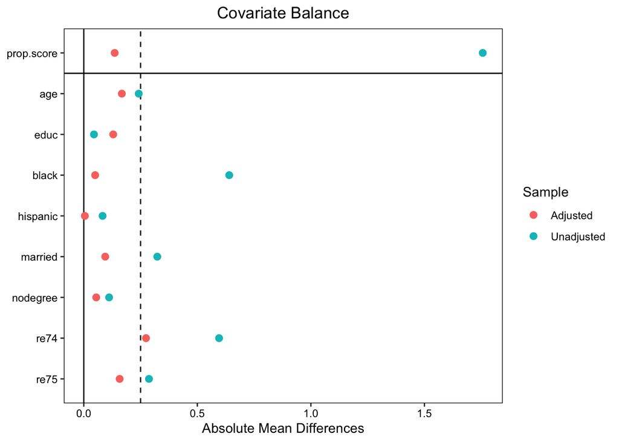

```r
love.plot(Weighted_Data, thresholds = 0.25, abs = TRUE)
```

最後にIPW推定量を計算してみましょう。ここは先ほどの面倒くさい方法と同じですが、重み付け変数は`weightit()`関数から得られたオブジェクト（`Weighted_Data`）の`weights`列を使用します。推定ができたら結果を出力します。

```r
IPW_Result <- lm(re78 ~ treat, data = Day2_df,
                 weights = Weighted_Data$weights)

summary(IPW_Result)
```

```
##
## Call:
## lm(formula = re78 ~ treat, data = Day2_df, weights = Weighted_Data$weights)
##
## Weighted Residuals:
##    Min     1Q Median     3Q    Max
## -42083  -6606  -2284   4979  77674
##
## Coefficients:
##             Estimate Std. Error t value Pr(>|t|)
## (Intercept)   6422.8      397.4  16.161   <2e-16
## treat          224.7      577.7   0.389    0.697
##
## Residual standard error: 9864 on 612 degrees of freedom
## Multiple R-squared:  0.0002471,  Adjusted R-squared:  -0.001386
## F-statistic: 0.1513 on 1 and 612 DF,  p-value: 0.6975
```

224.7という結果が得られましたが、これは{WeightIt}パッケージを使わなかった結果と完全に一致しますね。

# 付録

## ノンパラメトリック推定

ここではマハラノビス最近傍マッチングの例を使って、ATTを推定してみましょう。まずは、処置群の潜在的結果を統制群から割り当てて差分を算出し、その平均値を求るというのがノンパラメトリックな推定方法です。以下のコードが理解できるようになれば、他の最近傍マッチング（傾向スコアマッチングなど）も外部パッケージを使わずに計算できるようになります。

各処置群がどのケースとマッチングされたかはマッチングのオブジェクト名の後に`$match.matrix`を付けることで抽出できます。ちょっとやってみましょう。

```r
# 全部表示させると長くなんるので、最初の6行まで確認
head(MH.Matching$match.matrix)
```

```
##   [,1]
## 1 "553"
## 2 "557"
## 3 "478"
## 4 "567"
## 5 "579"
## 6 "438"
```

左が処置群、右が統制群ですね。それぞれケースのIDを抽出しましょう。

```r
# MH.Matching$match.matrixは1列の行列です。
# 処置群IDは行の名前として格納され、統制群IDは1列目に入っています。
MH.Treat   <- as.vector(row.names(MH.Matching$match.matrix))
MH.Control <- as.vector(MH.Matching$match.matrix[, 1])

# 中身を確認
print(MH.Treat)
```

```
##   [1] "1"   "2"   "3"   "4"   "5"   "6"   "7"   "8"   "9"   "10"  "11"  "12"
##  [13] "13"  "14"  "15"  "16"  "17"  "18"  "19"  "20"  "21"  "22"  "23"  "24"
##  [25] "25"  "26"  "27"  "28"  "29"  "30"  "31"  "32"  "33"  "34"  "35"  "36"
##  [37] "37"  "38"  "39"  "40"  "41"  "42"  "43"  "44"  "45"  "46"  "47"  "48"
##  [49] "49"  "50"  "51"  "52"  "53"  "54"  "55"  "56"  "57"  "58"  "59"  "60"
##  [61] "61"  "62"  "63"  "64"  "65"  "66"  "67"  "68"  "69"  "70"  "71"  "72"
##  [73] "73"  "74"  "75"  "76"  "77"  "78"  "79"  "80"  "81"  "82"  "83"  "84"
##  [85] "85"  "86"  "87"  "88"  "89"  "90"  "91"  "92"  "93"  "94"  "95"  "96"
##  [97] "97"  "98"  "99"  "100" "101" "102" "103" "104" "105" "106" "107" "108"
## [109] "109" "110" "111" "112" "113" "114" "115" "116" "117" "118" "119" "120"
## [121] "121" "122" "123" "124" "125" "126" "127" "128" "129" "130" "131" "132"
## [133] "133" "134" "135" "136" "137" "138" "139" "140" "141" "142" "143" "144"
## [145] "145" "146" "147" "148" "149" "150" "151" "152" "153" "154" "155" "156"
## [157] "157" "158" "159" "160" "161" "162" "163" "164" "165" "166" "167" "168"
## [169] "169" "170" "171" "172" "173" "174" "175" "176" "177" "178" "179" "180"
## [181] "181" "182" "183" "184" "185"
```

```r
print(MH.Control)
```

```
##   [1] "553" "557" "478" "567" "579" "438" "592" "528" "590" "564" "540" "566"
##  [13] "561" "608" "463" "552" "556" "544" "578" "547" "460" "473" "585" "537"
##  [25] "596" "563" "603" "524" "577" "525" "586" "604" "516" "558" "454" "581"
##  [37] "523" "571" "457" "527" "568" "422" "583" "450" "573" "359" "449" "451"
##  [49] "569" "570" "532" "565" "559" "374" "601" "594" "411" "600" "575" "538"
##  [61] "550" "420" "382" "384" "613" "468" "421" "464" "539" "584" "477" "588"
##  [73] "599" "430" "415" "396" "533" "526" "409" "574" "377" "426" "546" "609"
##  [85] "447" "529" "397" "508" "406" "509" "506" "598" "610" "522" "560" "513"
##  [97] "555" "593" "365" "429" "462" "458" "459" "542" "424" "511" "452" "562"
## [109] "400" "474" "504" "576" "520" "456" "445" "507" "344" "391" "443" "366"
## [121] "405" "461" "387" "497" "475" "351" "501" "370" "363" "399" "436" "311"
## [133] "362" "317" "352" "340" "410" "390" "353" "280" "442" "302" "333" "304"
## [145] "329" "321" "325" "338" "303" "319" "275" "301" "327" "328" "323" "339"
## [157] "343" "314" "259" "265" "320" "324" "277" "291" "257" "232" "271" "255"
## [169] "251" "247" "274" "261" "217" "235" "243" "220" "233" "269" "216" "202"
## [181] "192" "208" "191" "186" "193"
```

次は、元の`lalonde`データから処置群と統制群の結果変数 (`re78`)を抽出し、`MH.Matched.df`というデータフレームとしてまとめます。続いて、各ケースのITEを計算します。

```r
MH.Matched.df <- data.frame(
    Treat.ID   = MH.Treat,
    Control.ID = MH.Control,
    Treat.Y    = lalonde[MH.Treat,]$re78,
    Control.Y  = lalonde[MH.Control,]$re78
)

MH.Matched.df <- MH.Matched.df %>%
    mutate(ITE = Treat.Y - Control.Y)

DT::datatable(MH.Matched.df)
```

|  | Treat.ID | Control.ID | Treat.Y | Control.Y | ITE |
| --- | --- | --- | --- | --- | --- |
| 1 | 1 | 553 | 9930.046 | 0 | 9930.046 |
| 2 | 2 | 557 | 3595.894 | 6083.8 | -2487.906 |
| 3 | 3 | 478 | 24909.45 | 11023.84 | 13885.61 |
| 4 | 4 | 567 | 7506.146 | 0 | 7506.146 |
| 5 | 5 | 579 | 289.7899 | 2664.341 | -2374.5511 |
| 6 | 6 | 438 | 4056.494 | 1223.558 | 2832.936 |
| 7 | 7 | 592 | 0 | 3902.676 | -3902.676 |
| 8 | 8 | 528 | 8472.158 | 0 | 8472.158 |
| 9 | 9 | 590 | 2164.022 | 0 | 2164.022 |
| 10 | 10 | 564 | 12418.07 | 5841.453 | 6576.617 |

[output cut: 175 more lines]

1行目を見ると1は553とマッチングされ、それぞれの結果変数は9930.046ドル、0ドルです。その差分がITEであり、9930.046ドルですね。

これらITEの平均値がATTとなります。早速計算してみましょう。

```r
MH.ATT <- mean(MH.Matched.df$ITE)

print(MH.ATT)
```

```
## [1] 507.0434
```

ATTは約507.043ドルでした。回帰分析でやった結果と一致しますね。大人しく回帰分析でやりましょう。

## バランスチェック

これまでは主にQ-Q Plotを用いたバランスチェックを紹介しましたが、`MatchIt`パッケージは標準化差分/標準化バイアスのバランスチェックにも対応します。やり方としては、

```r
X <- matchit(...)
X.Blc <- summary(X, standardize = TRUE)

plot(X, interactive = FALSE)
```

です。たとえば、傾向スコアマッチングの例だと、

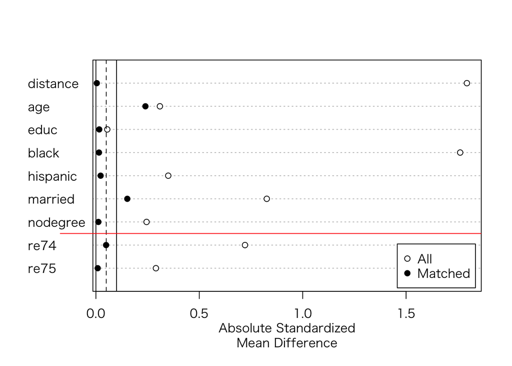

```r
PS.Blc <- summary(PS.Matching, standardize = TRUE)

plot(PS.Blc, interactive = FALSE)
abline(h = 0.25, col = "red")
```

もっと分かりやすい図がほしければ、これまで何回か使ってきました`cobalt`パッケージがおすすめです。

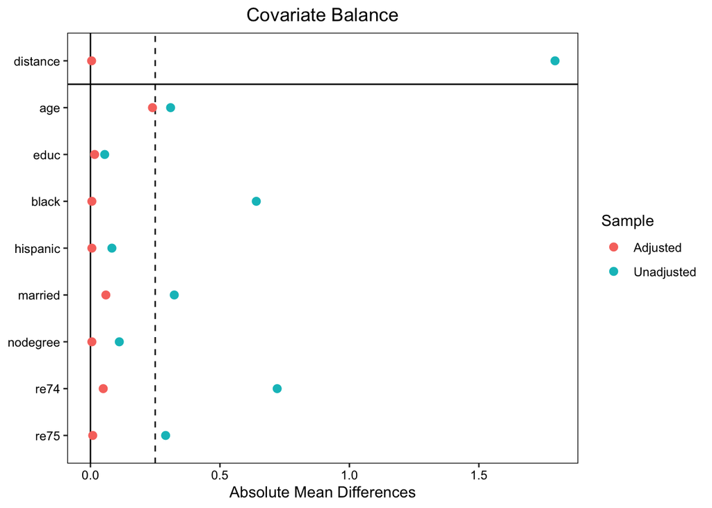

```r
library(cobalt)

love.plot(PS.Matching, threshold = 0.25, abs = TRUE)
```

他にも傾向スコアをマッチング前後に分けてヒストグラム化することもいいでしょう。

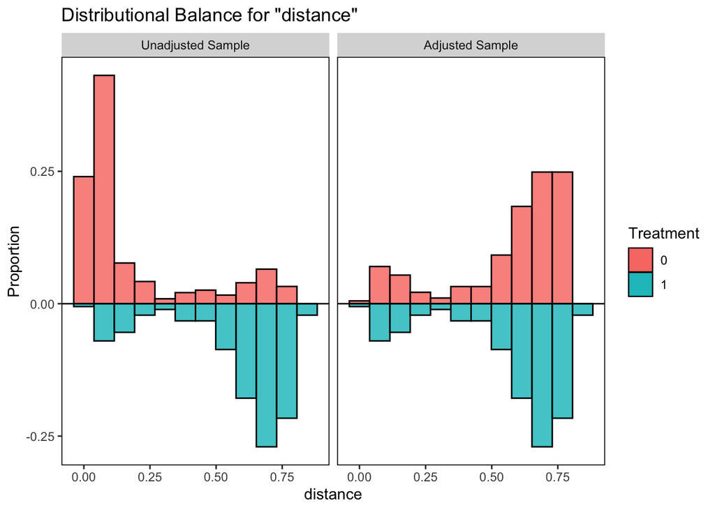

```r
bal.plot(PS.Matching, var.name = "distance", which = "both",
         type = "histogram", mirror = TRUE)
```

## 複数の手法を用いた場合、推定値の比較

これまでの推定値を同時に示す図を作ってみましょう。そのためには各推定結果のオブジェクトから処置変数の係数を抽出する必要があります。たとえば、重回帰分析によるATEの推定結果は`Raw_Fit2`に格納されています。`lm()`や`glm()`関数で行った推定結果から係数のみを抽出する関数は`coef()`です。

```r
coef(Raw_Fit2)
```

```
##   (Intercept)         treat           age          educ         black
##    66.5145197  1548.2438020    12.9776337   403.9412309 -1240.6440820
##      hispanic       married      nodegree          re74          re75
##   498.8968650   406.6208454   259.8173680     0.2963774     0.2315259
```

各係数の推定値がベクトルとして表示されます。ここで処置変数（`treat`）の係数はベクトルの2番目の要素であるため、`coef(Raw_Fit2)[2]`で抽出できます。他の手法による推定についても同じです。なぜなら、これまで処置変数を1番目の説明変数として使ってきたからです。

一方、標準誤差の抽出はちょっと面倒くさいです。いくつかの方法がありますが、ここでは`summary(オブジェクト名)$coef`を使います。推定結果を出力する`summary()`関数の`coef`要素を抽出すると以下のようなデータフレームが抽出されます。

```r
summary(Raw_Fit2)$coef
```

|  | Estimate | Std. Error | t value | Pr(>\|t\|) |
| --- | --- | --- | --- | --- |
| (Intercept) | 66.5145197 | 2436.7458028 | 0.0272965 | 0.9782323 |
| treat | 1548.2438020 | 781.2792975 | 1.9816778 | 0.0479682 |
| age | 12.9776337 | 32.4889061 | 0.3994482 | 0.6897042 |
| educ | 403.9412309 | 158.9062381 | 2.5420099 | 0.0112704 |
| black | -1240.6440820 | 768.7644071 | -1.6138157 | 0.1070897 |
| hispanic | 498.8968650 | 941.9425489 | 0.5296468 | 0.5965515 |
| married | 406.6208454 | 695.4723228 | 0.5846686 | 0.5589889 |
| nodegree | 259.8173680 | 847.4420524 | 0.3065901 | 0.7592610 |
| re74 | 0.2963774 | 0.0582726 | 5.0860483 | 0.0000005 |
| re75 | 0.2315259 | 0.1046199 | 2.2130198 | 0.0272694 |

ここで、`treat`の標準誤差は2行2列目に格納されていることが分かります。したがって、`treat`標準誤差は`summary(Raw_Fit2)$coef[2, 2]`で抽出できます。他にも`summary(Raw_Fit2)`から抽出できる要素は色々あります。興味のある方は`str(summary(Raw_Fit2))`で確認してみてください。

```r
Comparison.df <- data.frame(
    Method = c("Single Regression",
               "Multiple Regression",
               "Mahalanobis",
               "CEM",
               "Propensity Score",
               "IPW"),
    Est    = c(coef(Raw_Fit1)[2],
               coef(Raw_Fit2)[2],
               coef(MH_Fit)[2],
               coef(CEM_Fit)[2],
               coef(PS_Fit)[2],
               coef(IPW_Fit)[2]),
    SE     = c(summary(Raw_Fit1)$coef[2, 2],
               summary(Raw_Fit2)$coef[2, 2],
               summary(MH_Fit)$coef[2, 2],
               summary(CEM_Fit)$coef[2, 2],
               summary(PS_Fit)$coef[2, 2],
               summary(IPW_Fit)$coef[2, 2])
)
```

続いて、各手法名（`Method`列）を順序付きの変数に変換します。これをしないと、各手法がアルファベット順で並ぶことになります。順番が、データフレームに登場する順番の逆となります。したがって、`fct_inorder()`を使い、「登場順でfactor化」をし、`fct_rev()`で順番の反転を行います。`fct_*()`関数群は`forcats`パッケージが提供しており、詳細は[宋・矢内の第14章](https://www.jaysong.net/RBook/factor.html)を参照してください。

```r
Comparison.df <- Comparison.df %>%
  mutate(Method = fct_inorder(Method),
         Method = fct_rev(Method))
```

続きまして、95%信頼区間の下限（`LL`）と上限（`UL`）を追加し、$\alpha = 0.05$水準で統計的有意か否かを示す変数も作成します。

```r
Comparison.df <- Comparison.df %>%
    mutate(LL  = Est + qnorm(0.025) * SE,
           UL  = Est + qnorm(0.975) * SE,
           Sig = if_else(LL * UL > 0 , "Significant", "Insignificant"))
```

```r
Comparison.df
```

| Method | Est | SE | LL | UL | Sig |
| --- | --- | --- | --- | --- | --- |
| Single Regression | -635.0262 | 657.1374 | -1922.99190 | 652.9395 | Insignificant |
| Multiple Regression | 1548.2438 | 781.2793 | 16.96452 | 3079.5231 | Significant |
| Mahalanobis | 507.0434 | 746.8731 | -956.80109 | 1970.8878 | Insignificant |
| CEM | 1070.9073 | 1248.1293 | -1375.38120 | 3517.1959 | Insignificant |
| Propensity Score | 1967.9397 | 971.3786 | 64.07258 | 3871.8068 | Significant |
| IPW | 224.6763 | 577.6575 | -907.51150 | 1356.8641 | Insignificant |

宋のように「表より図がいい！」という方は以下のように可視化することも可能です。

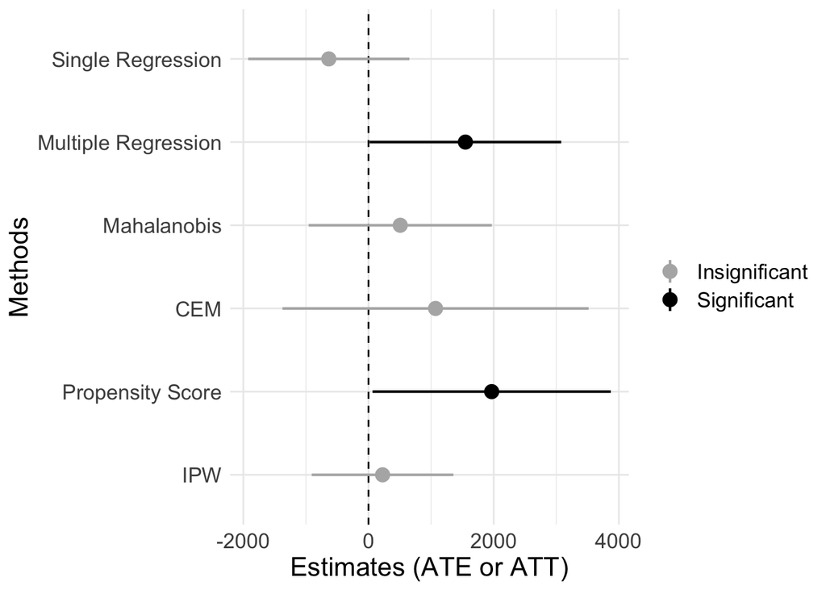

```r
Comparison.df %>%
    ggplot() +
    # x = 0の垂直線を引く。線の種類は破線 (linetype = 2)で
    geom_vline(xintercept = 0, linetype = 2) +
    # 点と線を同時に出力するgeom_pointrange幾何オブジェクトを使用
    # 点の位置 (x, y)はEst, Methodに、線の下限と上限 (xmin, xmax)はLL, UL
    # Sigの値によって色分けするためにcolor引数もマッピング
    geom_pointrange(aes(x = Est, y = Method, xmin = LL, xmax = UL,
                        color = Sig), size = 0.75) +
    # colorにマッピングされているSigの値がSignificantなら色をblackに
    # Insignificantならgray70にする
    scale_color_manual(values = c("Significant"   = "black",
                                  "Insignificant" = "gray70")) +
    # ラベルを付ける
    labs(y = "Methods", x = "Estimates (ATE or ATT)",
         color = "") +
    # minimalテーマを適用
    theme_minimal() +
    # 文字の大きさを調整
    theme(text = element_text(size = 16))
```

[^1]: lalondeデータセットを提供するパッケージは複数あり、それぞれデータセットの構成に違いがあります。どれを使っても実習には問題ございませんが、以下の内容を再現される場合は`data()`内に`package = "cobalt"`を指定するようにしましょう。
[^2]: これは重み変数を使わない最近傍マッチングをしても追加されます。ただし、その場合、`W`は全て1になります。
[^3]: 実は`nearest = "logit"`が省略されています。つまり、ロジスティック回帰分析から得られた傾向スコアの距離に基づくマッチングを意味します。
[^4]: ロジスティック回帰分析ではなくても問題ありません。他、プロッビット、サポートベクトルマシン、回帰木、判別分析、ニューラル・ネットワークなどもあり、これらを組わせることも可能です。
[^5]: [Imai, Kosuke and Marc Ratkovic. 2014. “Covariate Balancing Propensity Score.” *Journal of the Royal Statistical Society, Series B,* Vol. 76, No. 1, pp. 243-246.](https://imai.fas.harvard.edu/research/CBPS.html)
[^6]: Super Learnerを使った例は「Cyrus, Samii, Laura Paler, and Sarah Zukerman Daly. 2016. “Retrospective Causal Inference with Machine Learning Ensembles: An Application to Anti-recidivism Policies in Colombia.” *Political Analysis,* 22 (4) pp. 434-456」を、日本語による解説は担当教員の報告スライドを参照して下さい。